# Project: Investigating TMDB Dataset

[figure not shown]

- Introduction
- Data Wrangling
- Exploratory Data Analysis
- Conclusions

## Introduction

> There is no doubt that Film industry is one of the most idustries that have high revenues, the concept of paying millions of money on choosing the best crew, cast, locations and also sophisticated equipments to bring out a high quality movies which make much more revenue than what is paid, this is what makes good films companies are more wanted than others

> for this dataset which collected from TMDB we have some information about more than 10,000 movies like cast, budget, revenue and more so we will ask some question to know what are the factors of a good movie

> **Q1. Which genres that directors are focus on the most?**

> **Q2. which are the companies contributes in more movies than others?**

> **Q3. who is the best director?**

> **Q4. what affects revenue?**

but frist let's dive deeper in the dataset and see if it needs preproccessing first to be able to answer previous question

```python
# Use this cell to set up import statements for all of the packages that you
#   plan to use.
import pandas as pd
import numpy as np
import matplotlib.pyplot as plt
import seaborn as sns
%matplotlib inline

# Remember to include a 'magic word' so that your visualizations are plotted
#   inline with the notebook. See this page for more:
#   http://ipython.readthedocs.io/en/stable/interactive/magics.html
```

## Data Wrangling

### General Properties

```python
# Load your data and print out a few lines. Perform operations to inspect data
#   types and look for instances of missing or possibly errant data.
df = pd.read_csv("tmdb-movies.csv")
pd.set_option('display.max_columns', None)

df.head(3)
```

|  | id | imdb_id | popularity | budget | revenue | original_title | cast | homepage | director | tagline | keywords | overview | runtime | genres | production_companies | release_date | vote_count | vote_average | release_year | budget_adj | revenue_adj |
| --- | --- | --- | --- | --- | --- | --- | --- | --- | --- | --- | --- | --- | --- | --- | --- | --- | --- | --- | --- | --- | --- |
| 0 | 135397 | tt0369610 | 32.985763 | 150000000 | 1513528810 | Jurassic World | Chris Pratt\|Bryce Dallas Howard\|Irrfan Khan\|Vi... | http://www.jurassicworld.com/ | Colin Trevorrow | The park is open. | monster\|dna\|tyrannosaurus rex\|velociraptor\|island | Twenty-two years after the events of Jurassic ... | 124 | Action\|Adventure\|Science Fiction\|Thriller | Universal Studios\|Amblin Entertainment\|Legenda... | 6/9/15 | 5562 | 6.5 | 2015 | 1.379999e+08 | 1.392446e+09 |
| 1 | 76341 | tt1392190 | 28.419936 | 150000000 | 378436354 | Mad Max: Fury Road | Tom Hardy\|Charlize Theron\|Hugh Keays-Byrne\|Nic... | http://www.madmaxmovie.com/ | George Miller | What a Lovely Day. | future\|chase\|post-apocalyptic\|dystopia\|australia | An apocalyptic story set in the furthest reach... | 120 | Action\|Adventure\|Science Fiction\|Thriller | Village Roadshow Pictures\|Kennedy Miller Produ... | 5/13/15 | 6185 | 7.1 | 2015 | 1.379999e+08 | 3.481613e+08 |
| 2 | 262500 | tt2908446 | 13.112507 | 110000000 | 295238201 | Insurgent | Shailene Woodley\|Theo James\|Kate Winslet\|Ansel... | http://www.thedivergentseries.movie/#insurgent | Robert Schwentke | One Choice Can Destroy You | based on novel\|revolution\|dystopia\|sequel\|dyst... | Beatrice Prior must confront her inner demons ... | 119 | Adventure\|Science Fiction\|Thriller | Summit Entertainment\|Mandeville Films\|Red Wago... | 3/18/15 | 2480 | 6.3 | 2015 | 1.012000e+08 | 2.716190e+08 |

```python
#define the type and nan values in each feature
df.info()
```

```
<class 'pandas.core.frame.DataFrame'>
RangeIndex: 10866 entries, 0 to 10865
Data columns (total 21 columns):
id                      10866 non-null int64
imdb_id                 10856 non-null object
popularity              10866 non-null float64
budget                  10866 non-null int64
revenue                 10866 non-null int64
original_title          10866 non-null object
cast                    10790 non-null object
homepage                2936 non-null object
director                10822 non-null object
tagline                 8042 non-null object
keywords                9373 non-null object
overview                10862 non-null object
runtime                 10866 non-null int64
genres                  10843 non-null object
production_companies    9836 non-null object
release_date            10866 non-null object
vote_count              10866 non-null int64
vote_average            10866 non-null float64
release_year            10866 non-null int64
budget_adj              10866 non-null float64
revenue_adj             10866 non-null float64
dtypes: float64(4), int64(6), object(11)
memory usage: 1.7+ MB
```

```python
#to make it easy to know nan values
df.isnull().sum()
```

```
id                         0
imdb_id                   10
popularity                 0
budget                     0
revenue                    0
original_title             0
cast                      76
homepage                7930
director                  44
tagline                 2824
keywords                1493
overview                   4
runtime                    0
genres                    23
production_companies    1030
release_date               0
vote_count                 0
vote_average               0
release_year               0
budget_adj                 0
revenue_adj                0
dtype: int64
```

### Data Cleaning

> so we found that the missing values are in **imdb_id**, **cast**, **homepage**, **director**, **tagline**, **keywords**, **overview**, **genres**, **production_companies**

```python
#we don't need the duplicated values, so we will see how much duplicates we have
df.duplicated().sum()
```

```
1
```

```python
#now we drop them
df = df.drop_duplicates()
df.shape
```

```
(10865, 21)
```

```python
#as filling columns with a specific value could make the output misleading, we will fill nan values with "Unknown"
columns_list = ["cast",'director','tagline','keywords','genres','production_companies','overview']

for i in columns_list:
    df[i] = df[i].fillna("Unknown")
```

#### as the missing data in "homepage" are about 73% so we will drop it, and will drop "imdb_id" also, because we don't need it

```python
# After discussing the structure of the data and any problems that need to be
#   cleaned, perform those cleaning steps in the second part of this section.
df = df.drop(columns=["homepage","imdb_id"],axis = 1)
```

```python
#describe() is meant to show some describtive statistics for every feature in the dataset which make it easy to compute some value needed like mean, count and the inter-quartile ranges
df.describe()
```

|  | id | popularity | budget | revenue | runtime | vote_count | vote_average | release_year | budget_adj | revenue_adj |
| --- | --- | --- | --- | --- | --- | --- | --- | --- | --- | --- |
| count | 10865.000000 | 10865.000000 | 1.086500e+04 | 1.086500e+04 | 10865.000000 | 10865.000000 | 10865.000000 | 10865.000000 | 1.086500e+04 | 1.086500e+04 |
| mean | 66066.374413 | 0.646446 | 1.462429e+07 | 3.982690e+07 | 102.071790 | 217.399632 | 5.975012 | 2001.321859 | 1.754989e+07 | 5.136900e+07 |
| std | 92134.091971 | 1.000231 | 3.091428e+07 | 1.170083e+08 | 31.382701 | 575.644627 | 0.935138 | 12.813260 | 3.430753e+07 | 1.446383e+08 |
| min | 5.000000 | 0.000065 | 0.000000e+00 | 0.000000e+00 | 0.000000 | 10.000000 | 1.500000 | 1960.000000 | 0.000000e+00 | 0.000000e+00 |
| 25% | 10596.000000 | 0.207575 | 0.000000e+00 | 0.000000e+00 | 90.000000 | 17.000000 | 5.400000 | 1995.000000 | 0.000000e+00 | 0.000000e+00 |
| 50% | 20662.000000 | 0.383831 | 0.000000e+00 | 0.000000e+00 | 99.000000 | 38.000000 | 6.000000 | 2006.000000 | 0.000000e+00 | 0.000000e+00 |
| 75% | 75612.000000 | 0.713857 | 1.500000e+07 | 2.400000e+07 | 111.000000 | 146.000000 | 6.600000 | 2011.000000 | 2.085325e+07 | 3.370173e+07 |
| max | 417859.000000 | 32.985763 | 4.250000e+08 | 2.781506e+09 | 900.000000 | 9767.000000 | 9.200000 | 2015.000000 | 4.250000e+08 | 2.827124e+09 |

```python
#dropping values less than 15000 for budget and revenue
df = df.drop(df[df['revenue'] < 15000].index,axis = 0)
df = df.drop(df[df['budget'] < 15000].index,axis = 0)
```

```python
#now let's see changes happened for df.describe() after dropping undesired values
df.describe()
```

|  | id | popularity | budget | revenue | runtime | vote_count | vote_average | release_year | budget_adj | revenue_adj |
| --- | --- | --- | --- | --- | --- | --- | --- | --- | --- | --- |
| count | 3795.000000 | 3795.000000 | 3.795000e+03 | 3.795000e+03 | 3795.000000 | 3795.000000 | 3795.000000 | 3795.000000 | 3.795000e+03 | 3.795000e+03 |
| mean | 39715.188933 | 1.202932 | 3.766555e+07 | 1.093243e+08 | 109.398946 | 534.475362 | 6.173254 | 2001.248748 | 4.478980e+07 | 1.391159e+08 |
| std | 67250.462477 | 1.483295 | 4.231523e+07 | 1.774038e+08 | 19.860266 | 884.932750 | 0.792442 | 11.292946 | 4.486537e+07 | 2.171212e+08 |
| min | 5.000000 | 0.001117 | 1.500000e+04 | 1.507100e+04 | 26.000000 | 10.000000 | 2.200000 | 1960.000000 | 1.577503e+04 | 1.388176e+04 |
| 25% | 6008.500000 | 0.468087 | 1.000000e+07 | 1.456596e+07 | 96.000000 | 73.000000 | 5.700000 | 1995.000000 | 1.357265e+07 | 1.954091e+07 |
| 50% | 11282.000000 | 0.810805 | 2.500000e+07 | 4.639643e+07 | 106.000000 | 208.000000 | 6.200000 | 2004.000000 | 3.039101e+07 | 6.328856e+07 |
| 75% | 38356.500000 | 1.388100 | 5.000000e+07 | 1.263977e+08 | 119.000000 | 584.500000 | 6.700000 | 2010.000000 | 6.091278e+07 | 1.658204e+08 |
| max | 417859.000000 | 32.985763 | 4.250000e+08 | 2.781506e+09 | 338.000000 | 9767.000000 | 8.400000 | 2015.000000 | 4.250000e+08 | 2.827124e+09 |

```python
#see the values without the exponent added
df['budget'].min(), df['revenue'].min()
```

```
(15000, 15071)
```

```python
#we could say now that we don't have null values
df.isnull().sum()
```

```
id                      0
popularity              0
budget                  0
revenue                 0
original_title          0
cast                    0
director                0
tagline                 0
keywords                0
overview                0
runtime                 0
genres                  0
production_companies    0
release_date            0
vote_count              0
vote_average            0
release_year            0
budget_adj              0
revenue_adj             0
dtype: int64
```

## Exploratory Data Analysis

now let's go and see some descriptive statistics for this dataset

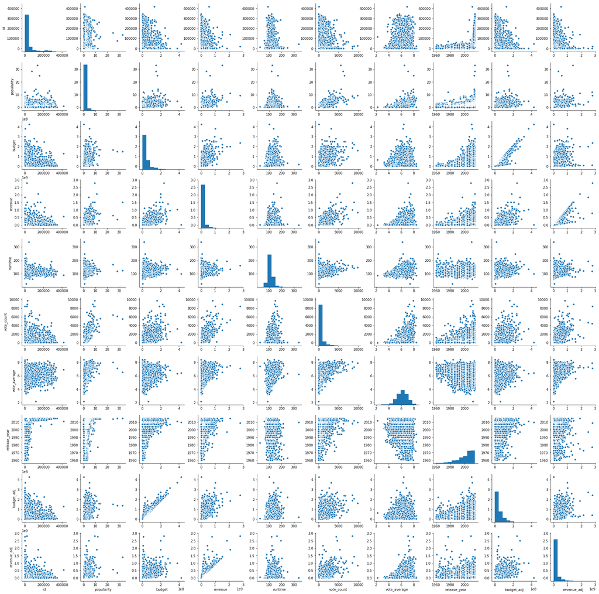

```python
#double-tap to see each plot clearly
#we use pairplot to see if there is a correlation between one feature and another and also see the distribution of each feature
sns.pairplot(df)
plt.figure(figsize=(17, 7))
```

> the histograms that takes the diagonal line are representing the distribution of each features and other scatterplots are representing the relation between every feature with each other

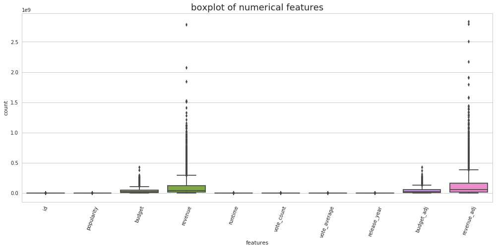

```python
#we can generate the output from .describe() by using boxplot to make more clear as boxplot represent a concept
#called five number summary which are the sample minimum, the lower quartile, the median, the upper quartile and the sample maximum
plt.figure(figsize=(17, 7))
sns.set(style="whitegrid")
sns.boxplot(data=df)

plt.xlabel('features')
plt.ylabel('count')
plt.title("boxplot of numerical features", fontsize=18)

plt.tick_params(axis='x', rotation=70)
```

> we can see that budget, revenue, budget_adj, revenue_adj have a lot of outliers, and that's predicted because it's something that has no limit unlike age we rarly see people higher than 100 years old

# Q1. Which genres that people are most like?

as some features have alot of values stored in each row, we will define a function that extract and generate countplots for the each value

```python
#this function can be applied for every feature that have more then 1 value separated with this sign '|'
def extract_info(df,feature,list_name,dict_name,head_number):
    var = df[feature].str.split("|")

    for i in var:
        for j in i:
            list_name.append(j)

    list_name = pd.Series(list_name)
    list_name = list_name.drop_duplicates()

    for i in list_name:
        dict_name[i] = df[df[feature].str.contains(i)].shape[0]
        new_df = pd.DataFrame(list(dict_name.items()),columns = [feature,'Count'])
        new_df = new_df.sort_values(by = "Count", ascending=False)


    return sns.barplot(new_df[feature].head(head_number),new_df['Count'].head(head_number)).set_title(feature+" counts", fontsize=18),plt.tick_params(axis='x', rotation=70),new_df.head()
```

```
(Text(0.5,1,'genres counts'), None,        genres  Count
 7       Drama   1732
 10     Comedy   1336
 3    Thriller   1184
 0      Action   1072
 1   Adventure    741)
```

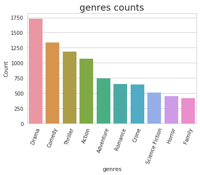

```python
#implementing extract_info for genres feature
genres_list = []
genres_dict = {}

extract_info(df,"genres",genres_list,genres_dict,10)
```

> so drama is most selected by directors and with big difference from second genre which is comedy

# Q2. which are the companies contributes in more movies than others?

```python
#let's see the number of movies that have budget higher than revenue and vice versa
print("number of movies having budget highr than revenue: ",df[df['budget'] >= df["revenue"]].shape[0])
print("number of movies having revenue highr than budget: ",df[df['budget'] < df["revenue"]].shape[0])
```

```
number of movies having budget highr than revenue:  1039
number of movies having revenue highr than budget:  2756
```

[output not shown]

```
(Text(0.5,1,'production_companies counts'),
 None,
      production_companies  Count
 39           Warner Bros.    353
 2052            Universal    345
 14     Universal Pictures    330
 34      Columbia Pictures    278
 23     Paramount Pictures    265)
```

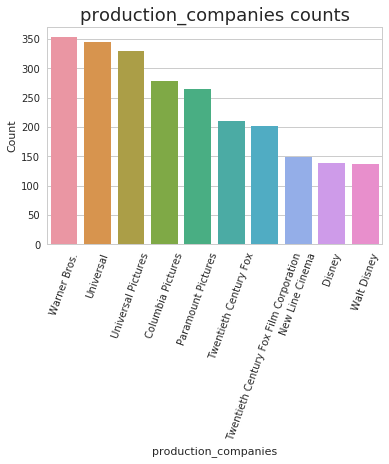

```python
#implementing extract_info for production_companies feature

production_companies_list = []
production_companies_dict = {}

extract_info(df,"production_companies",production_companies_list,production_companies_dict,10)
```

> this plot maybe misleading because it seems like Warner Bros is the most company that makes movies but, if we look deeper we would see that universal and universal pictures are actully the same company so we now can say that in first place universal pictures then Warner Bros

# Q3. who is the best directors?

there is no clear answer for this question as it depends on many factors, so we can investigate some of these factors and see who is the best director for each factor

factors that will focus on them are:

> **budget & revenue**, **runtime**, **vote count**, **vote average**

## Budget & Revenue

```python
#group directors with budget and revenue then make it in dscending order
Budget_and_Revenue = df.groupby("director")[["budget","revenue"]].sum().sort_values(by = "revenue", ascending=False)
Budget_and_Revenue.reset_index(inplace=True)
Budget_and_Revenue.head(5)
```

|  | director | budget | revenue |
| --- | --- | --- | --- |
| 0 | Steven Spielberg | 1551500000 | 9018563772 |
| 1 | Peter Jackson | 1326000000 | 6523244659 |
| 2 | James Cameron | 759900000 | 5841894863 |
| 3 | Michael Bay | 1360000000 | 4917208171 |
| 4 | Christopher Nolan | 1005000000 | 4167548502 |

## runtime

```python
#group directors with runtime then make it in dscending order
runtime = df.groupby("director")[["runtime"]].sum().sort_values(by = "runtime", ascending=False)
runtime = runtime.drop(index='Unknown', axis = 0)
runtime.reset_index(inplace=True)

runtime.head(5)
```

|  | director | runtime |
| --- | --- | --- |
| 0 | Steven Spielberg | 3657 |
| 1 | Clint Eastwood | 3117 |
| 2 | Ridley Scott | 2769 |
| 3 | Martin Scorsese | 2389 |
| 4 | Oliver Stone | 2114 |

## vote count

```python
#group directors with vote_count then make it in dscending order
vote_count = df.groupby("director")[["vote_count"]].sum().sort_values(by = "vote_count", ascending=False)
vote_count.reset_index(inplace=True)

vote_count.head(5)
```

|  | director | vote_count |
| --- | --- | --- |
| 0 | Christopher Nolan | 41561 |
| 1 | Steven Spielberg | 36284 |
| 2 | Peter Jackson | 31696 |
| 3 | Quentin Tarantino | 27855 |
| 4 | Ridley Scott | 24508 |

## vote average

```python
#group directors with vote_average then make it in dscending order
vote_average = df.groupby("director")[["vote_average"]].median().sort_values(by = "vote_average", ascending=False)
vote_average.reset_index(inplace=True)

vote_average.head(5)
```

|  | director | vote_average |
| --- | --- | --- |
| 0 | Damien Chazelle | 8.2 |
| 1 | Lenny Abrahamson | 8.0 |
| 2 | Xavier Dolan | 8.0 |
| 3 | Tony Kaye | 8.0 |
| 4 | Pete Docter | 8.0 |

```
Text(0.5,1,'directors who have the highest vote average')
```

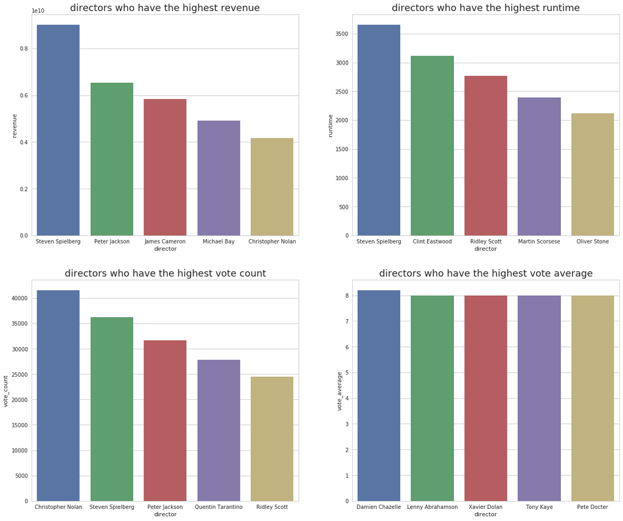

```python
#these are plots representing the relation of directors with Budget_and_Revenue, runtime, vote_count and vote_average
fig, axes = plt.subplots(nrows=2, ncols=2, figsize=[20, 17])

sns.barplot(Budget_and_Revenue["director"].head(5),Budget_and_Revenue["revenue"].head(5) , ax=axes[0,0]).set_title("directors who have the highest revenue", fontsize=18)

sns.barplot(runtime["director"].head(5),runtime["runtime"].head(5) , ax=axes[0,1]).set_title("directors who have the highest runtime", fontsize=18)

sns.barplot(vote_count["director"].head(5),vote_count["vote_count"].head(5), ax=axes[1,0]).set_title("directors who have the highest vote count", fontsize=18)

sns.barplot(vote_average["director"].head(5),vote_average["vote_average"].head(5) , ax=axes[1,1]).set_title("directors who have the highest vote average", fontsize=18)
```

> so we can notice that **steven spielberg** is almost in all of this features

## Q4. which factors affect revenue?

let's see the correlation between revenue and other numerical features

> we will choose correlations near to 1 or -1 which are:

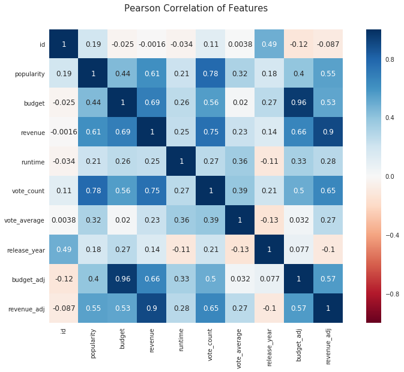

```python
#this heatmap is used to see the correlation between all features in the dataset
colormap = plt.cm.RdBu
plt.figure(figsize=(14,9))
plt.title('Pearson Correlation of Features', y=1.05, size=15)
sns.heatmap(df.corr(),vmax=1.0,vmin = -1,
            square=True, cmap=colormap, linecolor='white', annot=True)
```

> the most features that are correlated with revenue are: **popularity**, **budget**, **vote_count**, **budget_adj**, **revenue_adj**

```python
#now preparing the needed table to generate a lineplot
date = df.groupby("release_year")[["revenue",'budget']].sum().sort_values(by = "release_year", ascending=True)
date.reset_index(inplace=True)
date.head()
```

|  | release_year | revenue | budget |
| --- | --- | --- | --- |
| 0 | 1960 | 129005000 | 20806948 |
| 1 | 1961 | 337720188 | 38637000 |
| 2 | 1962 | 206329846 | 39450000 |
| 3 | 1963 | 176526882 | 61115000 |
| 4 | 1964 | 328613548 | 33935161 |

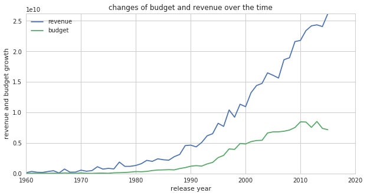

```python
#we will generate lineplot that represent the changes of budget and revenue over years
plt.figure(figsize=(10, 5))

plt.plot(date['release_year'],date['revenue'])
plt.plot(date['release_year'],date['budget'])

plt.xlim(1960, 2020)
plt.ylim(0, date['revenue'].max())


plt.xlabel('release year')
plt.ylabel('revenue and budget growth')

plt.title('changes of budget and revenue over the time')
plt.legend()
```

> we can see that revenue is increasing by the time while budget starts to decreasing since 2010

## Conclusions

so now we can have some clear answers about question that mentioned previously

### **Q1. Which genres that directors are focus on the most?**

so these 4 genres are more chosen by directors to focus on in their movies : **Drama**, **Comedy**, **Thriller** and **Action**

### **Q2. which are the companies contributes in more movies than others?**

by far, **Universal Pictures** have the highest number of contributing in movies production because universal and Universal Pictures are the same company, then comes **Warner Bros**, **Columbia Pictures** and **paramount Pictures**

### **Q3. who is the best director?**

as we said before, there is no clear answer for this question, so we tried to answer it according to some factors like **Budget & Revenue**, **runtime**, **vote count** and **vote Average** so,

> for **Budget & Revenue** we have **Steven Spielberg** ,

> for **runtime** we have also **Steven Spielberg**

> for **vote count** we have **Christopher Nolan** and in second place **Steven Spielberg**

> and finally for **vote Average** we have **Damien Chazelle**

so as overall we can say that Steven Spielberg is the most common name in these features

### **Q4. what affects revenue?**

as we have numerical and categorical features, we need to deal with them separatly, so

> for numerical features we applied pearson's correlation to see which features are more related to **revenue** and they are **popularity**, **budget**, **vote_count**, **budget_adj** and **revenue_adj**

> for categorical features it's hard to apply ordinary correlation checks because each feature have more than two levels, means that each feature have alot of values in it so we will leave them for now

## the limitaions i have faced in this project

**1 -** as i mentioned in Q4, it's hard to represent the correlation between discrete variable and categorical variables that have large number of values, for example if had a variable called gender, then it will have two classes: male and female, but for variable like cast we have a lot of actors and actress's names that represent large number of classes

after some research i found that there are some statistics techniques, mention in this questions on qoura, and found this picture as a good compilation of these techniques but the implementaion for some of them is beyond my experience and some others i used only in machine learning and don't know how exactly use them in this case

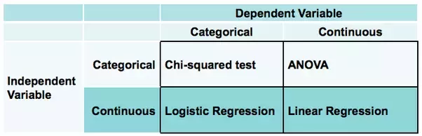

**2 -** some features had more than one value or string in one row, for example, genres feature have this value in first row **Action|Adventure|Science Fiction|Thriller**, separating this feature could end with representing some misleading plots

**3 -** in feature like **production_companies** some values has different names but actully they are the thing, for example universal and Universal Pictures each one of them were second and third in the plot respectivily put actully they are the same company and by combining them together they become in the first place, so for me there wasn't a clear way to fix this issue

```python
from subprocess import call
call(['python', '-m', 'nbconvert', 'Investigate_a_Dataset.ipynb'])
```

```
0
```